# Step One - Choose Your Data Set

###### We choose Titanic data set to analyze , it Contains demographics data and passenger information from 891 of the 2224 passengers and crew on board the Titanic ship.

To invesigate this data set , we have to pose some questions and we will try our best to answer these questions by using python especially Pandas and Numpy libraries.

Q1. what are the percentage of the survived people ?

Q2. There are many factors played vital role for survived poeple , what are they ?

Q3. what are the ages of the most survived people ?

Q5. Is there any correlation between survival factor and people's finincal status ?

### Data Dictionary

" Variable Definition Key survival Survival 0 = No, 1 = Yes

pclass Ticket class 1 = 1st, 2 = 2nd, 3 = 3rd

sex Sex Age Age in years  
sibsp # of siblings / spouses aboard the Titanic  
parch # of parents / children aboard the Titanic  
ticket Ticket number  
fare Passenger fare  
cabin Cabin number  
embarked Port of Embarkation C = Cherbourg, Q = Queenstown, S = Southampton Variable Notes

pclass: A proxy for socio-economic status (SES) 1st = Upper 2nd = Middle 3rd = Lower

age: Age is fractional if less than 1. If the age is estimated, is it in the form of xx.5

sibsp: The dataset defines family relations in this way... Sibling = brother, sister, stepbrother, stepsister Spouse = husband, wife (mistresses and fiancés were ignored)

parch: The dataset defines family relations in this way... Parent = mother, father Child = daughter, son, stepdaughter, stepson Some children travelled only with a nanny, therefore parch=0 for them. " [1]

```python
# to use Pandas and Numpy libraries , we have to import them into our code as can be see in the below import pandas as pd
import numpy  as np
import pandas as pd
# to be able to plot the data and see graphic or histogram diagrams ,we have to include the below library in our code
import matplotlib.pyplot as plt
import seaborn as sns

# to be able to plot Visualizations as well


from IPython.display import display
%matplotlib inline
```

```python
# the below code is to read data from the titanic cvs file using pandas library.
pf = pd.read_csv('titanic-data.csv')
```

# Data Exploration:

```python
# we use head function to return first rows in the titanic file , we limit it to 25
pf.head(25)
```

|  | PassengerId | Survived | Pclass | Name | Sex | Age | SibSp | Parch | Ticket | Fare | Cabin | Embarked |
| --- | --- | --- | --- | --- | --- | --- | --- | --- | --- | --- | --- | --- |
| 0 | 1 | 0 | 3 | Braund, Mr. Owen Harris | male | 22.0 | 1 | 0 | A/5 21171 | 7.2500 | NaN | S |
| 1 | 2 | 1 | 1 | Cumings, Mrs. John Bradley (Florence Briggs Th... | female | 38.0 | 1 | 0 | PC 17599 | 71.2833 | C85 | C |
| 2 | 3 | 1 | 3 | Heikkinen, Miss. Laina | female | 26.0 | 0 | 0 | STON/O2. 3101282 | 7.9250 | NaN | S |
| 3 | 4 | 1 | 1 | Futrelle, Mrs. Jacques Heath (Lily May Peel) | female | 35.0 | 1 | 0 | 113803 | 53.1000 | C123 | S |
| 4 | 5 | 0 | 3 | Allen, Mr. William Henry | male | 35.0 | 0 | 0 | 373450 | 8.0500 | NaN | S |
| 5 | 6 | 0 | 3 | Moran, Mr. James | male | NaN | 0 | 0 | 330877 | 8.4583 | NaN | Q |
| 6 | 7 | 0 | 1 | McCarthy, Mr. Timothy J | male | 54.0 | 0 | 0 | 17463 | 51.8625 | E46 | S |
| 7 | 8 | 0 | 3 | Palsson, Master. Gosta Leonard | male | 2.0 | 3 | 1 | 349909 | 21.0750 | NaN | S |
| 8 | 9 | 1 | 3 | Johnson, Mrs. Oscar W (Elisabeth Vilhelmina Berg) | female | 27.0 | 0 | 2 | 347742 | 11.1333 | NaN | S |
| 9 | 10 | 1 | 2 | Nasser, Mrs. Nicholas (Adele Achem) | female | 14.0 | 1 | 0 | 237736 | 30.0708 | NaN | C |
| 10 | 11 | 1 | 3 | Sandstrom, Miss. Marguerite Rut | female | 4.0 | 1 | 1 | PP 9549 | 16.7000 | G6 | S |
| 11 | 12 | 1 | 1 | Bonnell, Miss. Elizabeth | female | 58.0 | 0 | 0 | 113783 | 26.5500 | C103 | S |
| 12 | 13 | 0 | 3 | Saundercock, Mr. William Henry | male | 20.0 | 0 | 0 | A/5. 2151 | 8.0500 | NaN | S |
| 13 | 14 | 0 | 3 | Andersson, Mr. Anders Johan | male | 39.0 | 1 | 5 | 347082 | 31.2750 | NaN | S |
| 14 | 15 | 0 | 3 | Vestrom, Miss. Hulda Amanda Adolfina | female | 14.0 | 0 | 0 | 350406 | 7.8542 | NaN | S |
| 15 | 16 | 1 | 2 | Hewlett, Mrs. (Mary D Kingcome) | female | 55.0 | 0 | 0 | 248706 | 16.0000 | NaN | S |
| 16 | 17 | 0 | 3 | Rice, Master. Eugene | male | 2.0 | 4 | 1 | 382652 | 29.1250 | NaN | Q |
| 17 | 18 | 1 | 2 | Williams, Mr. Charles Eugene | male | NaN | 0 | 0 | 244373 | 13.0000 | NaN | S |
| 18 | 19 | 0 | 3 | Vander Planke, Mrs. Julius (Emelia Maria Vande... | female | 31.0 | 1 | 0 | 345763 | 18.0000 | NaN | S |
| 19 | 20 | 1 | 3 | Masselmani, Mrs. Fatima | female | NaN | 0 | 0 | 2649 | 7.2250 | NaN | C |
| 20 | 21 | 0 | 2 | Fynney, Mr. Joseph J | male | 35.0 | 0 | 0 | 239865 | 26.0000 | NaN | S |
| 21 | 22 | 1 | 2 | Beesley, Mr. Lawrence | male | 34.0 | 0 | 0 | 248698 | 13.0000 | D56 | S |
| 22 | 23 | 1 | 3 | McGowan, Miss. Anna "Annie" | female | 15.0 | 0 | 0 | 330923 | 8.0292 | NaN | Q |
| 23 | 24 | 1 | 1 | Sloper, Mr. William Thompson | male | 28.0 | 0 | 0 | 113788 | 35.5000 | A6 | S |
| 24 | 25 | 0 | 3 | Palsson, Miss. Torborg Danira | female | 8.0 | 3 | 1 | 349909 | 21.0750 | NaN | S |

```python
# we tail function in Pandas library to show the last rows in the titanic file and we limit the results to 10 rows of data
pf.tail(10)
```

|  | PassengerId | Survived | Pclass | Name | Sex | Age | SibSp | Parch | Ticket | Fare | Cabin | Embarked |
| --- | --- | --- | --- | --- | --- | --- | --- | --- | --- | --- | --- | --- |
| 881 | 882 | 0 | 3 | Markun, Mr. Johann | male | 33.0 | 0 | 0 | 349257 | 7.8958 | NaN | S |
| 882 | 883 | 0 | 3 | Dahlberg, Miss. Gerda Ulrika | female | 22.0 | 0 | 0 | 7552 | 10.5167 | NaN | S |
| 883 | 884 | 0 | 2 | Banfield, Mr. Frederick James | male | 28.0 | 0 | 0 | C.A./SOTON 34068 | 10.5000 | NaN | S |
| 884 | 885 | 0 | 3 | Sutehall, Mr. Henry Jr | male | 25.0 | 0 | 0 | SOTON/OQ 392076 | 7.0500 | NaN | S |
| 885 | 886 | 0 | 3 | Rice, Mrs. William (Margaret Norton) | female | 39.0 | 0 | 5 | 382652 | 29.1250 | NaN | Q |
| 886 | 887 | 0 | 2 | Montvila, Rev. Juozas | male | 27.0 | 0 | 0 | 211536 | 13.0000 | NaN | S |
| 887 | 888 | 1 | 1 | Graham, Miss. Margaret Edith | female | 19.0 | 0 | 0 | 112053 | 30.0000 | B42 | S |
| 888 | 889 | 0 | 3 | Johnston, Miss. Catherine Helen "Carrie" | female | NaN | 1 | 2 | W./C. 6607 | 23.4500 | NaN | S |
| 889 | 890 | 1 | 1 | Behr, Mr. Karl Howell | male | 26.0 | 0 | 0 | 111369 | 30.0000 | C148 | C |
| 890 | 891 | 0 | 3 | Dooley, Mr. Patrick | male | 32.0 | 0 | 0 | 370376 | 7.7500 | NaN | Q |

```python
#we use describe function to see the characteristics (e.g mean , stand deviation etc) of each column for pf data frame.
pf.describe()
```

|  | PassengerId | Survived | Pclass | Age | SibSp | Parch | Fare |
| --- | --- | --- | --- | --- | --- | --- | --- |
| count | 891.000000 | 891.000000 | 891.000000 | 714.000000 | 891.000000 | 891.000000 | 891.000000 |
| mean | 446.000000 | 0.383838 | 2.308642 | 29.699118 | 0.523008 | 0.381594 | 32.204208 |
| std | 257.353842 | 0.486592 | 0.836071 | 14.526497 | 1.102743 | 0.806057 | 49.693429 |
| min | 1.000000 | 0.000000 | 1.000000 | 0.420000 | 0.000000 | 0.000000 | 0.000000 |
| 25% | 223.500000 | 0.000000 | 2.000000 | 20.125000 | 0.000000 | 0.000000 | 7.910400 |
| 50% | 446.000000 | 0.000000 | 3.000000 | 28.000000 | 0.000000 | 0.000000 | 14.454200 |
| 75% | 668.500000 | 1.000000 | 3.000000 | 38.000000 | 1.000000 | 0.000000 | 31.000000 |
| max | 891.000000 | 1.000000 | 3.000000 | 80.000000 | 8.000000 | 6.000000 | 512.329200 |

```python
# we use len to check the length of the data frame , and we use unique function to check wether they are unique or not.
lenght_of_unique_data = len(pf['PassengerId'].unique())
print 'The length of unique data is:',lenght_of_unique_data
```

```
The length of unique data is: 891
```

```python
# that gives us indicator there's no duplication in the data , however , we will do double check by using duplicated function
# we use sum function to count the number of duplicats instead of showing all data.
duplicate_data = pf.duplicated()
print 'The number of duplicat data is:',duplicate_data.sum()
```

```
The number of duplicat data is: 0
```

```python
# we use dtypes function in pandas to see the datatypes for the columns in the data frame.s
pf.dtypes
```

```
PassengerId      int64
Survived         int64
Pclass           int64
Name            object
Sex             object
Age            float64
SibSp            int64
Parch            int64
Ticket          object
Fare           float64
Cabin           object
Embarked        object
dtype: object
```

```python
# we use info function to see specific details for each column ,e.g how many columns the dataframe has , how many values in each column and is there any nulls ??
pf.info()
```

```
<class 'pandas.core.frame.DataFrame'>
RangeIndex: 891 entries, 0 to 890
Data columns (total 12 columns):
PassengerId    891 non-null int64
Survived       891 non-null int64
Pclass         891 non-null int64
Name           891 non-null object
Sex            891 non-null object
Age            714 non-null float64
SibSp          891 non-null int64
Parch          891 non-null int64
Ticket         891 non-null object
Fare           891 non-null float64
Cabin          204 non-null object
Embarked       889 non-null object
dtypes: float64(2), int64(5), object(5)
memory usage: 83.6+ KB
```

## Data Wrangling:

```python
# As can be seen above in the exploration phase ,  there are NaNs in the cabin, age and embarked columns , we should remove it or take the mean for the column. So , here for data preparation , we will substitute nan with 0s by using fillna function
new_pf= pf.fillna(0)
# we fill the missing values in the ages with mean
new_age=pf['Age'].fillna(29.699118)
#pf['Cabin'].fillna(0)
```

```python
# we sort the values based on the two columns survived and pcalss and it would ascending for survived column and descending for the pclass column
new_pf.sort_values(['Survived','Pclass'], ascending=[True, False])
```

|  | PassengerId | Survived | Pclass | Name | Sex | Age | SibSp | Parch | Ticket | Fare | Cabin | Embarked |
| --- | --- | --- | --- | --- | --- | --- | --- | --- | --- | --- | --- | --- |
| 0 | 1 | 0 | 3 | Braund, Mr. Owen Harris | male | 22.0 | 1 | 0 | A/5 21171 | 7.2500 | 0 | S |
| 4 | 5 | 0 | 3 | Allen, Mr. William Henry | male | 35.0 | 0 | 0 | 373450 | 8.0500 | 0 | S |
| 5 | 6 | 0 | 3 | Moran, Mr. James | male | 0.0 | 0 | 0 | 330877 | 8.4583 | 0 | Q |
| 7 | 8 | 0 | 3 | Palsson, Master. Gosta Leonard | male | 2.0 | 3 | 1 | 349909 | 21.0750 | 0 | S |
| 12 | 13 | 0 | 3 | Saundercock, Mr. William Henry | male | 20.0 | 0 | 0 | A/5. 2151 | 8.0500 | 0 | S |
| 13 | 14 | 0 | 3 | Andersson, Mr. Anders Johan | male | 39.0 | 1 | 5 | 347082 | 31.2750 | 0 | S |
| 14 | 15 | 0 | 3 | Vestrom, Miss. Hulda Amanda Adolfina | female | 14.0 | 0 | 0 | 350406 | 7.8542 | 0 | S |
| 16 | 17 | 0 | 3 | Rice, Master. Eugene | male | 2.0 | 4 | 1 | 382652 | 29.1250 | 0 | Q |
| 18 | 19 | 0 | 3 | Vander Planke, Mrs. Julius (Emelia Maria Vande... | female | 31.0 | 1 | 0 | 345763 | 18.0000 | 0 | S |
| 24 | 25 | 0 | 3 | Palsson, Miss. Torborg Danira | female | 8.0 | 3 | 1 | 349909 | 21.0750 | 0 | S |
| 26 | 27 | 0 | 3 | Emir, Mr. Farred Chehab | male | 0.0 | 0 | 0 | 2631 | 7.2250 | 0 | C |
| 29 | 30 | 0 | 3 | Todoroff, Mr. Lalio | male | 0.0 | 0 | 0 | 349216 | 7.8958 | 0 | S |
| 37 | 38 | 0 | 3 | Cann, Mr. Ernest Charles | male | 21.0 | 0 | 0 | A./5. 2152 | 8.0500 | 0 | S |
| 38 | 39 | 0 | 3 | Vander Planke, Miss. Augusta Maria | female | 18.0 | 2 | 0 | 345764 | 18.0000 | 0 | S |
| 40 | 41 | 0 | 3 | Ahlin, Mrs. Johan (Johanna Persdotter Larsson) | female | 40.0 | 1 | 0 | 7546 | 9.4750 | 0 | S |
| 42 | 43 | 0 | 3 | Kraeff, Mr. Theodor | male | 0.0 | 0 | 0 | 349253 | 7.8958 | 0 | C |
| 45 | 46 | 0 | 3 | Rogers, Mr. William John | male | 0.0 | 0 | 0 | S.C./A.4. 23567 | 8.0500 | 0 | S |
| 46 | 47 | 0 | 3 | Lennon, Mr. Denis | male | 0.0 | 1 | 0 | 370371 | 15.5000 | 0 | Q |
| 48 | 49 | 0 | 3 | Samaan, Mr. Youssef | male | 0.0 | 2 | 0 | 2662 | 21.6792 | 0 | C |
| 49 | 50 | 0 | 3 | Arnold-Franchi, Mrs. Josef (Josefine Franchi) | female | 18.0 | 1 | 0 | 349237 | 17.8000 | 0 | S |
| 50 | 51 | 0 | 3 | Panula, Master. Juha Niilo | male | 7.0 | 4 | 1 | 3101295 | 39.6875 | 0 | S |
| 51 | 52 | 0 | 3 | Nosworthy, Mr. Richard Cater | male | 21.0 | 0 | 0 | A/4. 39886 | 7.8000 | 0 | S |
| 57 | 58 | 0 | 3 | Novel, Mr. Mansouer | male | 28.5 | 0 | 0 | 2697 | 7.2292 | 0 | C |
| 59 | 60 | 0 | 3 | Goodwin, Master. William Frederick | male | 11.0 | 5 | 2 | CA 2144 | 46.9000 | 0 | S |
| 60 | 61 | 0 | 3 | Sirayanian, Mr. Orsen | male | 22.0 | 0 | 0 | 2669 | 7.2292 | 0 | C |
| 63 | 64 | 0 | 3 | Skoog, Master. Harald | male | 4.0 | 3 | 2 | 347088 | 27.9000 | 0 | S |
| 67 | 68 | 0 | 3 | Crease, Mr. Ernest James | male | 19.0 | 0 | 0 | S.P. 3464 | 8.1583 | 0 | S |
| 69 | 70 | 0 | 3 | Kink, Mr. Vincenz | male | 26.0 | 2 | 0 | 315151 | 8.6625 | 0 | S |
| 71 | 72 | 0 | 3 | Goodwin, Miss. Lillian Amy | female | 16.0 | 5 | 2 | CA 2144 | 46.9000 | 0 | S |
| 73 | 74 | 0 | 3 | Chronopoulos, Mr. Apostolos | male | 26.0 | 1 | 0 | 2680 | 14.4542 | 0 | C |
| ... | ... | ... | ... | ... | ... | ... | ... | ... | ... | ... | ... | ... |
| 710 | 711 | 1 | 1 | Mayne, Mlle. Berthe Antonine ("Mrs de Villiers") | female | 24.0 | 0 | 0 | PC 17482 | 49.5042 | C90 | C |
| 712 | 713 | 1 | 1 | Taylor, Mr. Elmer Zebley | male | 48.0 | 1 | 0 | 19996 | 52.0000 | C126 | S |
| 716 | 717 | 1 | 1 | Endres, Miss. Caroline Louise | female | 38.0 | 0 | 0 | PC 17757 | 227.5250 | C45 | C |
| 724 | 725 | 1 | 1 | Chambers, Mr. Norman Campbell | male | 27.0 | 1 | 0 | 113806 | 53.1000 | E8 | S |
| 730 | 731 | 1 | 1 | Allen, Miss. Elisabeth Walton | female | 29.0 | 0 | 0 | 24160 | 211.3375 | B5 | S |
| 737 | 738 | 1 | 1 | Lesurer, Mr. Gustave J | male | 35.0 | 0 | 0 | PC 17755 | 512.3292 | B101 | C |
| 740 | 741 | 1 | 1 | Hawksford, Mr. Walter James | male | 0.0 | 0 | 0 | 16988 | 30.0000 | D45 | S |
| 742 | 743 | 1 | 1 | Ryerson, Miss. Susan Parker "Suzette" | female | 21.0 | 2 | 2 | PC 17608 | 262.3750 | B57 B59 B63 B66 | C |
| 759 | 760 | 1 | 1 | Rothes, the Countess. of (Lucy Noel Martha Dye... | female | 33.0 | 0 | 0 | 110152 | 86.5000 | B77 | S |
| 763 | 764 | 1 | 1 | Carter, Mrs. William Ernest (Lucile Polk) | female | 36.0 | 1 | 2 | 113760 | 120.0000 | B96 B98 | S |
| 765 | 766 | 1 | 1 | Hogeboom, Mrs. John C (Anna Andrews) | female | 51.0 | 1 | 0 | 13502 | 77.9583 | D11 | S |
| 779 | 780 | 1 | 1 | Robert, Mrs. Edward Scott (Elisabeth Walton Mc... | female | 43.0 | 0 | 1 | 24160 | 211.3375 | B3 | S |
| 781 | 782 | 1 | 1 | Dick, Mrs. Albert Adrian (Vera Gillespie) | female | 17.0 | 1 | 0 | 17474 | 57.0000 | B20 | S |
| 796 | 797 | 1 | 1 | Leader, Dr. Alice (Farnham) | female | 49.0 | 0 | 0 | 17465 | 25.9292 | D17 | S |
| 802 | 803 | 1 | 1 | Carter, Master. William Thornton II | male | 11.0 | 1 | 2 | 113760 | 120.0000 | B96 B98 | S |
| 809 | 810 | 1 | 1 | Chambers, Mrs. Norman Campbell (Bertha Griggs) | female | 33.0 | 1 | 0 | 113806 | 53.1000 | E8 | S |
| 820 | 821 | 1 | 1 | Hays, Mrs. Charles Melville (Clara Jennings Gr... | female | 52.0 | 1 | 1 | 12749 | 93.5000 | B69 | S |
| 829 | 830 | 1 | 1 | Stone, Mrs. George Nelson (Martha Evelyn) | female | 62.0 | 0 | 0 | 113572 | 80.0000 | B28 | 0 |
| 835 | 836 | 1 | 1 | Compton, Miss. Sara Rebecca | female | 39.0 | 1 | 1 | PC 17756 | 83.1583 | E49 | C |
| 839 | 840 | 1 | 1 | Marechal, Mr. Pierre | male | 0.0 | 0 | 0 | 11774 | 29.7000 | C47 | C |
| 842 | 843 | 1 | 1 | Serepeca, Miss. Augusta | female | 30.0 | 0 | 0 | 113798 | 31.0000 | 0 | C |
| 849 | 850 | 1 | 1 | Goldenberg, Mrs. Samuel L (Edwiga Grabowska) | female | 0.0 | 1 | 0 | 17453 | 89.1042 | C92 | C |
| 853 | 854 | 1 | 1 | Lines, Miss. Mary Conover | female | 16.0 | 0 | 1 | PC 17592 | 39.4000 | D28 | S |
| 856 | 857 | 1 | 1 | Wick, Mrs. George Dennick (Mary Hitchcock) | female | 45.0 | 1 | 1 | 36928 | 164.8667 | 0 | S |
| 857 | 858 | 1 | 1 | Daly, Mr. Peter Denis | male | 51.0 | 0 | 0 | 113055 | 26.5500 | E17 | S |
| 862 | 863 | 1 | 1 | Swift, Mrs. Frederick Joel (Margaret Welles Ba... | female | 48.0 | 0 | 0 | 17466 | 25.9292 | D17 | S |
| 871 | 872 | 1 | 1 | Beckwith, Mrs. Richard Leonard (Sallie Monypeny) | female | 47.0 | 1 | 1 | 11751 | 52.5542 | D35 | S |
| 879 | 880 | 1 | 1 | Potter, Mrs. Thomas Jr (Lily Alexenia Wilson) | female | 56.0 | 0 | 1 | 11767 | 83.1583 | C50 | C |
| 887 | 888 | 1 | 1 | Graham, Miss. Margaret Edith | female | 19.0 | 0 | 0 | 112053 | 30.0000 | B42 | S |
| 889 | 890 | 1 | 1 | Behr, Mr. Karl Howell | male | 26.0 | 0 | 0 | 111369 | 30.0000 | C148 | C |

891 rows × 12 columns

```python
# after cleaning the data , we want to check whether there's any nulls or not by using isnull() function,+ .sum() to aggregate or sum up the data based on the null values
new_pf.isnull().sum()
```

```
PassengerId    0
Survived       0
Pclass         0
Name           0
Sex            0
Age            0
SibSp          0
Parch          0
Ticket         0
Fare           0
Cabin          0
Embarked       0
dtype: int64
```

```python
# we want to check the values of the survived columns ,so we use value counts
new_pf['Survived'].value_counts()
```

```
0    549
1    342
Name: Survived, dtype: int64
```

```python
# we want to get the count of survival people for the gender
survived_people = new_pf[new_pf['Survived']==1]['Sex'].value_counts()
print (survived_people)
```

```
female    233
male      109
Name: Sex, dtype: int64
```

```python
# we want to get the count of Died people for the gender
Died_people = new_pf[new_pf['Survived']==0]['Sex'].value_counts()
print (Died_people)
```

```
male      468
female     81
Name: Sex, dtype: int64
```

```python
# now, we will put them in a new data frame to combine them in it and show the number of survival men besides women and died people along with their genders in a table as below
new_df =pd.DataFrame([survived_people,Died_people],index=['Survived','Died people'])
new_df
```

|  | female | male |
| --- | --- | --- |
| Survived | 233 | 109 |
| Died people | 81 | 468 |

## Q1. what are the percentage of the survived people ?

```python
# we will be answer this question by calculating the total number of survival people and total passenger on the ship and get the percentage
number_Of_survived_people = new_pf[new_pf['Survived']==1].Survived.sum()
print 'The number of survival people:',number_Of_survived_people
print'The number of survival people by sex : ', survived_people
total_number_passengers= new_pf['Survived'].count()
print 'The total number of Passengers',total_number_passengers


The_Percentage_of_survived_people = (float(( number_Of_survived_people / float(total_number_passengers))*100))
print 'The percentage of the survived people ', The_Percentage_of_survived_people,'%'
```

```
The number of survival people: 342
The number of survival people by sex :  female    233
male      109
Name: Sex, dtype: int64
The total number of Passengers 891
The percentage of the survived people  38.3838383838 %
```

##### From Above anaylsis , we found out that the percentage of the survived people is 38.38%. Further , The number of the survived people is 342, 233 were female and 109 were men. So,most of the survival are female as can be shown in the below plots.

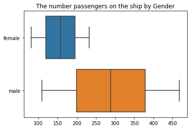

```python
#different plot to show the number of female and male passengers on the ship
sns.boxplot( data=new_df, orient='h');
plt.title('The number passengers on the ship by Gender')
```

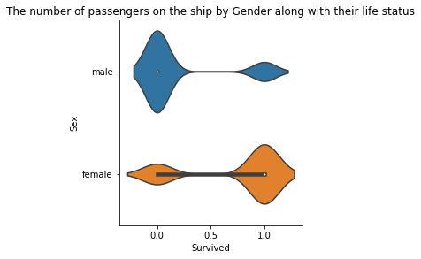

```python
# different visulization to compare the survived people to dead people for gender
jk = sns.factorplot( 'Survived','Sex',  data=new_pf, kind="violin")
plt.title('The number of passengers on the ship by Gender along with their life status')
```

In the above plot , we found out theres more men were died than women on the ship

## Q2. There are many factors played vital role for survived poeple , what are they ?

```python
# as we did above , we will check pclass column values
new_pf['Pclass'].value_counts()
```

```
3    491
1    216
2    184
Name: Pclass, dtype: int64
```

```python
# we want to get the count of survival people for the Pclass
survived_people_Pclass = new_pf[new_pf['Survived']==1]['Pclass'].value_counts()
print (survived_people_Pclass)
```

```
1    136
3    119
2     87
Name: Pclass, dtype: int64
```

```python
# we want to get the count of Died people for the Pclass
Died_people_Pclass = new_pf[new_pf['Survived']==0]['Pclass'].value_counts()
print (Died_people_Pclass)
```

```
3    372
2     97
1     80
Name: Pclass, dtype: int64
```

```python
# now, we will put them in a new data frame to combine them in it and show the number of survival men besides women and died people along with their genders in a table as below
new_df_Pclass =pd.DataFrame([survived_people_Pclass,Died_people_Pclass],index=['Survived','Died people'])
new_df_Pclass
```

|  | 1 | 2 | 3 |
| --- | --- | --- | --- |
| Survived | 136 | 87 | 119 |
| Died people | 80 | 97 | 372 |

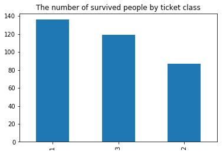

```python
# we visualize the people whome survived by class
new_subset = new_pf[new_pf["Survived"]==1]

pd.value_counts(new_subset['Pclass']).plot(kind='bar')
plt.title('The number of survived people by ticket class')
```

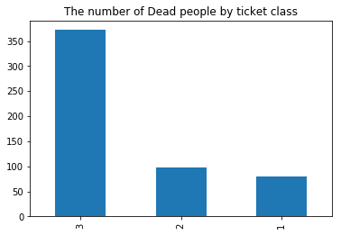

```python
# we visualize the people whome did not survive by class
new_subset = new_pf[new_pf["Survived"]==0]

pd.value_counts(new_subset['Pclass']).plot(kind='bar')
plt.title('The number of Dead people by ticket class')
```

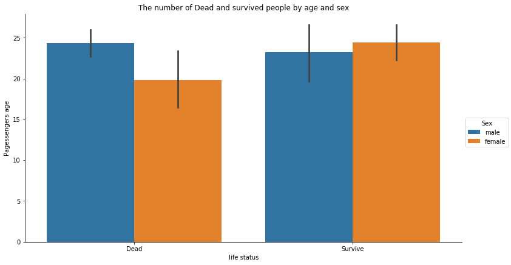

```python
# # we created a plot to show the age and pclass across the life status
plot_three= sns.factorplot(x="Survived", y="Age", hue='Sex', data=new_pf, kind="bar", size=6, aspect=1.8)


(plot_three.set_axis_labels('life status', 'Pagessengers age')
    .set_xticklabels(["Dead", "Survive"])

)
plt.title('The number of Dead and survived people by age and sex')
```

## Q5. Is there any correlation between survival factor and people's finincal status ?

```python
# we created convert fare function to replace fare number with range(string) to help us in further analysis
def convert_Fare(Fare):
    if Fare <= 10:
           return '< 10'
    elif Fare > 10 and Fare <= 30:
           return ' 10 - 30 '
    elif Fare >30  and Fare <= 50:
           return '30 - 50'
    elif Fare > 50 and Fare <= 90:
           return '50 - 90'
    elif Fare >90 and Fare <= 250:
           return '90 - 250'
    else:
           return '> 250 '
```

```python
# we applyed the function in our data frame new_pf, and put it in the new_fare
new_Fare  = new_pf["Fare"].map(convert_Fare)


xx= new_Fare[new_pf['Survived']==1].max()
print xx
```

```
> 250
```

```python
# we created convert age function to replace age number with range(string) to help us in further analysis
def convert_age(age):
    if age >=0 and age <= 5:
           return 'age group 0 - 5'
    elif age >=6 and age <= 12:
           return 'age group 6 - 12 '
    elif age >=13 and age <=20:
           return 'age group 13 - 20'
    elif age >=21 and age <= 42:
           return 'age group 21 - 42'
    elif age >=43 and age < 60:
           return 'age group 43 - 60'
    else:
           return 'age group > 60 '
```

```python
#  we created the convert ages that uses applymap,but we won't use it in our analysis
def convert_ages(ages):
    return ages.applymap(convert_age)
```

```python
# we applyed the function in our data frame new_pf, and put it in the new_data
new_data  = new_age.map(convert_age)




xx= new_data[new_pf['Survived']==1].max()
print 'The oldest one whome survived on the titanic  was on :',xx
```

```
The oldest one whome survived on the titanic  was on : age group > 60
```

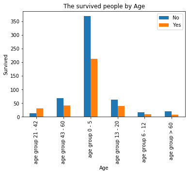

```python
# we grouped the data frame for the column survived and Pclass and visulize it in the bar plot as shown in the below diagram
The_survived_people_by_class = new_pf.groupby([new_data, 'Survived']).size().unstack('Survived')
The_survived_people_by_class.columns = ['No', 'Yes']

The_survived_people_by_class.plot.bar(title='The survived people by Age');
sns.barplot(new_data, new_pf["Survived"], palette="Set1");
```

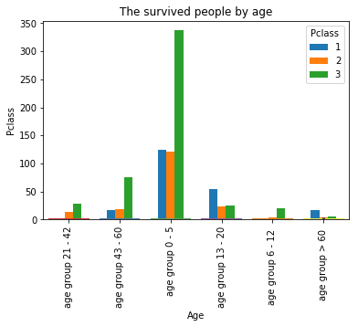

```python
# we group  the data by comparing the age group to the pclass
The_survived_people_by_age = new_pf.groupby([new_data, 'Pclass']).size().unstack('Pclass')
The_survived_people_by_age.columns

The_survived_people_by_age.plot.bar(title='The survived people by age');
sns.barplot(new_data, new_pf["Pclass"], palette="Set1");
```

```python
# we use max to get the oldest one who survived during the incident
survived_people = new_pf[new_pf['Survived']==1]['Age'].max()
print (survived_people)
```

```
80.0
```

From above analysis , we found out the oldest one of the survival people is 80 and the oldest of the dead people is 74 as in the below analysis

```python
 # we use max to get the oldest one who died during the incident
Died_people_Pclass = new_pf[new_pf['Survived']==0]['Age'].max()
print (Died_people_Pclass)
```

```
74.0
```

```python
 # we use max to get the youngest one who died during the incident
survived_people = new_pf[new_pf['Survived']==1]['Age'].min()
print (survived_people)
```

```
0.0
```

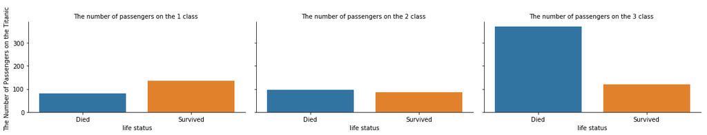

```python
# we visulizae the data for our data frame based on survived and pclass column and it shows the number passenger per class and their live statu's died or alive
gx = sns.factorplot('Survived', col='Pclass', data=new_pf, kind='count', size=3, aspect=1.8)



(gx.set_axis_labels('life status', 'The Number of Passengers on the Titanic ')
    .set_xticklabels(['Died', 'Survived'])
    .set_titles("The number of passengers on the {col_name} class ")
)
```

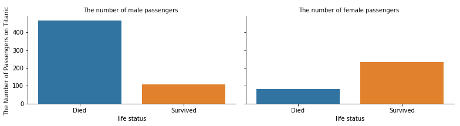

```python
# we visulizae the data for our data frame based on survived and pclass column and it shows the number passenger per class and their live statu's died or alive


gxg = sns.factorplot('Survived', col='Sex', data=new_pf, kind='count', size=3, aspect=1.8)



(gxg.set_axis_labels('life status', 'The Number of Passengers on Titanic ')
    .set_xticklabels(['Died', 'Survived'])
    .set_titles("The number of {col_name} passengers ")

)
```

# Conclusion:

#### From the above analysis , we found out the oldest age to survive on the ship was 80. Further, the youngest was 0. That's due to the missing values in the data set. Moreover, analysis has shown that most people who were in the first class had higher chancies to live more than other classes becuase it's in the upper level. Nevertheless, most people who were in the third class had the highest rate of death and that's becuase it's located in third level.

#### In Conclusion, people who are rich had higher chancies to live more than poor people. So , there's a correlation between financial status and survival factor in people's lives. In future, we will use correlate function to see is any other correlation.

## Limitations:

#### - Missing values in the data set is one of the limitations in this data. The age column has more than 150 missing value which could make our analysis bais.

#### - The sample that was chosen is not that big , which could give wrong results in the analysis.

References:

[1] https://www.kaggle.com/c/titanic/data

[2] https://seaborn.pydata.org/generated/seaborn.barplot.html

[3] https://seaborn.pydata.org/examples/horizontal_barplot.html

[4] https://pandas.pydata.org/pandas-docs/stable/generated/pandas.DataFrame.unstack.html

[5] http://pandas.pydata.org/pandas-docs/stable/groupby.html

[6] https://www.youtube.com/watch?v=oH3wYKvwpJ8

[7] https://seaborn.pydata.org/generated/seaborn.factorplot.html